# Identification of Severe Weather Events Most Harmful to Population Health and Economy

Keh-Harng Feng

February 19, 2017

## Synopsis

Data from the NOAA storm database is analyzed to identify the most harmful severe weather events when it comes to population health and economy. Event type identifiers from the original dataset is first extensively cleaned up using regular expressions. Two indices, the casualty index and ecodamage index are then computed to represent the overall harm from a specific type of weather event. COLD SNOW is found to be the most dangerous weather event to population health while HURRICANE is the most economically damaging.

## Data Processing

The data set used is a csv file prepared by Roger D. Peng using the U.S. National Oceanic and Atmospheric Administration storm database.

### Data Ingress

The data is downloaded and load into R as a compressed csv file:

```r
if (!file.exists('StormData.csv.bz2')) {
    download.file('https://d396qusza40orc.cloudfront.net/repdata%2Fdata%2FStormData.csv.bz2',
                  destfile = 'StormData.csv.bz2')
}

if (!('data' %in% ls())) {
    data <- read.csv('StormData.csv.bz2')
}
```

### Event Type Clean-up

A sample of unique storm event types from the data set is listed below

```r
head(sort(unique(data$EVTYPE)), 20)
```

```
##  [1]    HIGH SURF ADVISORY   COASTAL FLOOD          FLASH FLOOD
##  [4]  LIGHTNING              TSTM WIND              TSTM WIND (G45)
##  [7]  WATERSPOUT             WIND                  ?
## [10] ABNORMAL WARMTH        ABNORMALLY DRY         ABNORMALLY WET
## [13] ACCUMULATED SNOWFALL   AGRICULTURAL FREEZE    APACHE COUNTY
## [16] ASTRONOMICAL HIGH TIDE ASTRONOMICAL LOW TIDE  AVALANCE
## [19] AVALANCHE              BEACH EROSIN
## 985 Levels:    HIGH SURF ADVISORY  COASTAL FLOOD ... WND
```

Unfortunately the list contains MANY typographical errors. A method is devised to identify and correct *some* of them automatically.

An ‘cleanup’ function is written to first correct many of the common typos and group together types that are considered similar. It then gets rid of numbers and special characters or phrases like ‘AND’ in the event type (except for ones that are in ‘Summary’). It extracts “words” without spaces and other symbols (plus the word ‘AND’) in an event type and convert them to upper cases. The cleaned up event type is then regenerated using paste().

```r
# Helper function to
# 1. Convert to upper case and correct typos.
# 2. Fuzzy group categories.
cleanup <- function(x) {
    x <- toupper(x)

    # Typo/redundancy corrections
    # A
    x <- gsub('AVALANCE', 'AVALANCHE', x, fixed = TRUE)
    x <- gsub(' ANDBLOWING', '', x, fixed = TRUE)
    x <- gsub('ABNORMAL.* ', 'EXCESSIVE', x)

    # C
    x <- gsub('CSTL', 'COASTAL', x, fixed = TRUE)
    x <- gsub('CLOUDS', 'CLOUD', x, fixed = TRUE)

    # D
    x <- gsub('DEVEL', 'DEVIL', x, fixed = TRUE)
    x <- gsub(' DAMAGE.*', '', x)

    # E
    x <- gsub('EROSIN', 'EROSION', x, fixed = TRUE)
    x <- gsub('EXTREME', 'EXCESSIVE', x, fixed = TRUE)
    x <- gsub('EXTENDED', 'EXCESSIVE', x, fixed = TRUE)
    x <- gsub(' EFFECTS', '', x, fixed = TRUE)

    # F
    x <- gsub('FIRES', 'FIRE', x, fixed = TRUE)
    x <- gsub('FLOODS', 'FLOOD', x, fixed = TRUE)
    x <- gsub('FLOODING', 'FLOOD', x, fixed = TRUE)
    x <- gsub('FLD', 'FLOOD', x, fixed = TRUE)
    x <- gsub('FLDG', 'FLOOD', x, fixed = TRUE)
    x <- gsub('FUNNELS', 'FUNNEL', x, fixed = TRUE)

    # H
    x <- gsub('HEAVY', 'EXCESSIVE', x, fixed = TRUE)
    x <- gsub('HIGH', 'EXCESSIVE', x, fixed = TRUE)
    x <- gsub('HVY ', '', x, fixed = TRUE)

    # L
    x <- gsub('LIGHTING', 'LIGHTNING', x, fixed = TRUE)
    x <- gsub('LIGNTNING', 'LIGHTNING', x, fixed = TRUE)

    # M
    x <- gsub('MIRCO', 'MICRO', x, fixed = TRUE)
    x <- gsub('MPH', '', x, fixed = TRUE)
    x <- gsub('MISHAP', 'ACCIDENT', x, fixed = TRUE)

    # R
    x <- gsub('RECORD', 'EXCESSIVE', x, fixed = TRUE)

    # S
    x <- gsub('SEVERE', 'EXCESSIVE', x, fixed = TRUE)
    x <- gsub('SPELL', '', x, fixed = TRUE)
    x <- gsub('SML', 'SMALL', x, fixed = TRUE)
    x <- gsub('STRM', 'STREAM', x, fixed = TRUE)
    x <- gsub('STROM', 'STORM', x, fixed = TRUE)
    x <- gsub('SORM', 'STORM', x, fixed = TRUE)
    x <- gsub('STORMS', 'STORM', x, fixed = TRUE)
    x <- gsub('STRONG', 'EXCESSIVE', x, fixed = TRUE)
    x <- gsub(' SEAS[ $]', 'SEA', x)

    # T
    x <- gsub('TEMPERATURES', 'TEMPERATURE', x, fixed = TRUE)
    x <- gsub('TEMP$', 'TEMPERATURE', x)
    x <- gsub('TIDES', 'TIDE', x, fixed = TRUE)
    x <- gsub('TORNDAO', 'TORNADO', x, fixed = TRUE)
    x <- gsub('TORNADO.*', 'TORNADO', x)
    x <- gsub('TUNDERSTORM', 'THUNDERSTORM', x, fixed = TRUE)
    x <- gsub('TORRENTIAL', 'EXCESSIVE', x, fixed = TRUE)
    x <- gsub('THUNDERTORM', 'THUNDERSTORM', x, fixed = TRUE)
    x <- gsub('THU.*STORM', 'THUNDERSTORM', x)
    x <- gsub('.*TSTM.*', 'THUNDERSTORM', x)



    # U
    x <- gsub('UNSEASON.* ', 'EXCESSIVE', x)
    x <- gsub('UNUS.* ', 'EXCESSIVE', x)

    # V
    x <- gsub('VOG', 'FOG', x, fixed = TRUE)
    x <- gsub('VERY', 'EXCESSIVE', x, fixed = TRUE)

    # W
    x <- gsub('WINDS', 'WIND', x, fixed = TRUE)
    x <- gsub('WINDCHILL', 'WIND CHILL', x, fixed = TRUE)
    x <- gsub('WND', 'WIND', x, fixed = TRUE)
    x <- gsub('WAYTER', 'WATER', x, fixed = TRUE)
    x <- gsub('WATER.*SPOUT.*', 'WATERSPOUT', x)

    # Category Collapse
    # High Priority: the following are processed first (therefore most likely
    # will override other checks)
    x <- gsub('.*BLIZZARD.*', 'BLIZZARD', x)
    x <- gsub('^BLOWING SNOW.*', 'EXCESSIVE SNOW', x)
    x <- gsub('.*FOG.*', 'FOG', x)
    x <- gsub('.*FLOOD.*', 'FLOOD', x)
    x <- gsub('.*THUNDERSTORM.*', 'THUNDERSTORM', x)
    x <- gsub('EXCESSIVE SNOW.*', 'EXCESSIVE SNOW', x)
    x <- gsub('LIGHTNING.*', 'LIGHTNING', x)
    x <- gsub('^EXCESSIVE.*SEA', 'ROUGH SEA', x)
    x <- gsub('^EXCESSIVE.*HEAT.*', 'EXCESSIVE HEAT', x)

    # Normal priority
    x <- gsub('ACCUMULATED SNOWFALL', 'EXCESSIVE SNOW', x, fixed = TRUE)

    x <- gsub('^BEACH EROSION.*', 'BEACH EROSION', x)
    x <- gsub('^BITTER WIND CHILL.*', 'WIND CHILL', x)



    x <- gsub('^COASTAL.*(FLOOD|SURGE).*', 'COASTAL FLOOD', x)
    x <- gsub('COLD WEATHER', 'EXCESSIVE COLD', x, fixed = TRUE)
    x <- gsub('^COLD WIND.*', 'EXCESSIVE COLD', x)
    x <- gsub('^COLD$', 'EXCESSIVE COLD', x, fixed = TRUE)


    x <- gsub('DAM BREAK', 'DAM FAILURE', x, fixed = TRUE)
    x <- gsub('DAMAGING FREEZE', 'COLD TEMPERATURE', x, fixed = TRUE)
    x <- gsub('.*DOWNBURST.*', 'DOWNBURST', x)
    x <- gsub('^DRY.*', 'DRY', x)
    x <- gsub('DRIEST MONTH', 'DROUGHT', x, fixed = TRUE)
    x <- gsub('^DROUGHT.*', 'DROUGHT', x)
    x <- gsub('^DUST DEVIL.*', 'DUST DEVIL', x)

    x <- gsub('^EROSION COASTAL.*', 'COASTAL FLOOD EROSION', x)
    x <- gsub('.*EXCESSIVE.*RAIN.*', 'EXCESSIVE RAIN', x)
    x <- gsub('.*WIND.*CHILL.*', 'EXCESSIVE WIND CHILL', x)

    x <- gsub('.*HAIL.*', 'HAIL', x)
    x <- gsub('^HURRICANE.*', 'HURRICANE', x)
    x <- gsub('HEAT DROUGHT', 'DROUGHT', x, fixed = TRUE)
    x <- gsub('^HEAT.*DROUGHT', 'DROUGHT', x)
    x <- gsub('^HEAT .*', 'HEAT', x)

    if (grepl('.*ICE STORM.*', x)) {
        x <- 'ICE STORM'
    } else if(grepl('(ICE|ICY)', x)) {
        x <- 'EXCESSIVE ICE'
    }

    x <- gsub('LIGHT SNOW.*', 'LIGHT SNOW', x)


    x <- gsub('MICROBURST.*', 'MICROBURST', x)
    x <- gsub('MUD.*SLIDE.*', 'MUDSLIDE', x)

    x <- gsub('^FROST.*', 'FROST', x)
    x <- gsub('FUNNEL CLOUD HAIL', 'HAIL', x, fixed = TRUE)

    x <- gsub('^GLAZE.*', 'GLAZE', x)

    x <- gsub('GROUND BLIZZARD', 'BLIZZARD', x, fixed = TRUE)
    x <- gsub('^GUSTNADO.*', 'GUSTNADO', x)
    x <- gsub('^GUSTY.*', 'GUSTY WIND', x)

    x <- gsub('^RAIN FLOODING', 'FLOOD', x)
    x <- gsub('^RAIN.*', 'RAIN', x)
    x <- gsub('RAIN', 'EXCESSIVE RAIN', x)

    x <- gsub('^STORM .*', 'STORM', x)
    x <- gsub('^SNOW .*', 'SNOW', x)
    x <- gsub('^SNOWCOLD', 'SNOW', x)

    x <- gsub('^TROPICAL STORM.*', 'TROPICAL STORM', x)
    x <- gsub('TYPHOON', 'TROPICAL STORM', x, fixed = TRUE)

    x <- gsub('^URBAN SMALL STREAM.*', 'FLOOD', x)

    x <- gsub('VOLANIC ASH.*', 'VOLCANIC ASH', x)

    x <- gsub('WATERSPROUT.*', 'WATERSPROUT', x)
    x <- gsub('^WILD.*FIRE.*', 'WILDFIRE', x)
    x <- gsub('WINTER STORM.*', 'WINTER STORM', x)
    x <- gsub('WINTER WEATHER.*', 'WINTER WEATHER', x)

    # Only carry out number eradication on events that are not "Summary"
    if (!grepl('^SUMMARY', x)) {
        x <- gsub('[0-9\\.]', '', x)
    }

    x <- gsub('AND', '&', x)
    vec <- strsplit(x, '[ &/\\(\\)]')[[1]]
    x <- paste(vec[sapply(vec, nchar) > 0], collapse = ' ')

}

new_data <- data
new_data$EVTYPE <- sapply(new_data$EVTYPE, FUN = cleanup)
```

The event types with automatic cleanup are listed below:

```r
print(unique(sort(new_data$EVTYPE)), quote = TRUE)
```

```
##   [1] "?"
##   [2] "AGRICULTURAL FREEZE"
##   [3] "APACHE COUNTY"
##   [4] "ASTRONOMICAL EXCESSIVE TIDE"
##   [5] "ASTRONOMICAL LOW TIDE"
##   [6] "AVALANCHE"
##   [7] "BEACH EROSION"
##   [8] "BELOW NORMAL PRECIPITATION"
##   [9] "BLIZZARD"
##  [10] "BLOW-OUT TIDE"
##  [11] "BLOWING DUST"
##  [12] "BRUSH FIRE"
##  [13] "COASTAL EROSION"
##  [14] "COASTAL FLOOD"
##  [15] "COASTAL STORM"
```

[output cut: 317 more lines]

### Property Damage Representation

```r
scale <- function(x){
    x <- toupper(x)
    if (x %in% c('K', 'M', 'B', '1', '2', '3', '4', '5', '6', '7', '8', '9')){
        if (x == 'K') {
            return(1000)
        } else if (x == 'M') {
            return(1e6)
        } else if (x == 'B') {
            return(1e9)
        } else {
            return(1*10^(as.numeric(x)))
        }
    } else {
        return(0)
    }
}

PROPLOSS <- new_data$PROPDMG*sapply(new_data$PROPDMGEXP, FUN = scale)
```

A similar process is carried out to combine ‘CROPDMG’ and ‘CROPDMGEXP’ into a single variable ‘CROPLOSS’ that represents the amount of dollars lost from crop damage.

```r
CROPLOSS <- new_data$CROPDMG*sapply(new_data$CROPDMGEXP, FUN = scale)

new_data <- cbind(new_data[, !(names(new_data) %in% c('CROPDMG', 'CROPDMGEXP',
                                                    'PROPDMG', 'PROPDMGEXP'))],
                  PROPLOSS, CROPLOSS)
```

## Result

### Most Harmful Event to Health

The most harmful event to personal health is identified by the use of **casualty index**. The casualty index (CI) is calculated by doing a weighted sum of the averages of the number of injuries and the number of fatalities per occurrence of event grouped by severe weather event types stored in the ‘EVTYPE’ variable.

It is important to compute the casualty index as a weighted sum of averages as opposed to just a weighted sum because

1. A sum will skewer results towards years where the number of recorded observations are high.
2. A sum will also skewer results towards event types that happen more frequently.

The weighting assigned for injuries:fatalities is one to two, meaning a fatality carries twice as much impact compared to an injury. The code to compute CI is included here:

```r
avg <- aggregate(new_data[c('INJURIES', 'FATALITIES')], by = list(new_data$EVTYPE),
                 FUN = mean, na.rm = TRUE)

CI <- cbind(avg[1], avg[2] + avg[3]*2)

names(CI) <- c('EVTYPE', 'CASUALTY_INDEX')
```

A plot of the top 20 events by casualty index is shown below.

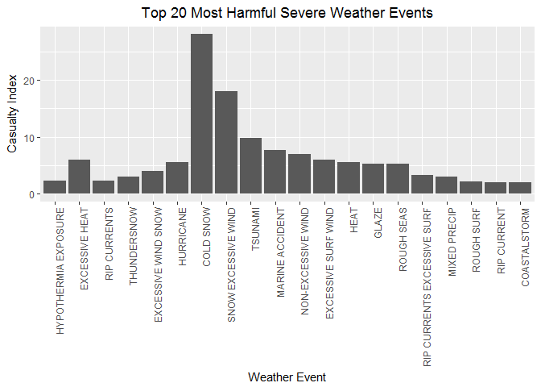

```r
perm <- order(CI$CASUALTY_INDEX, decreasing = TRUE)
CI <- CI[perm,]
CI$EVTYPE <- factor(CI$EVTYPE, levels = CI$EVTYPE[perm])

library('ggplot2')

ggplot(CI[1:20,], aes(x = EVTYPE[1:20], y = CASUALTY_INDEX[1:20])) +
    geom_bar(stat = 'identity') +
    xlab('Weather Event') +
    ylab('Casualty Index') +
    ggtitle('Top 20 Most Harmful Severe Weather Events') +
    theme(axis.text.x = element_text(angle = 90, hjust = 1),
          plot.title = element_text(hjust = 0.5))
```

From the bar plot it is clear that **COLD SNOW** is the most harmful severe weather event when it comes to personal safety.

### Most Economically Damaging

The most economically damaging event is identified by the use of the **ecodamage index**, EI. This is just a straight sum of the average amount of monetary loss from both property loss and crop loss per severe weather event separated by event type. Note that the sum is not weighted, hence both property loss and crop loss are considered to have equal economical impact.

```r
avg <- aggregate(new_data[c('PROPLOSS', 'CROPLOSS')], by = list(new_data$EVTYPE),
                 FUN = mean, na.rm = TRUE)

EI <- cbind(avg[1], avg[2] + avg[3])
names(EI) <- c('EVTYPE', 'ECODMG_INDEX')
```

A plot of the top 20 most economically damaging severe weather events is shown below.

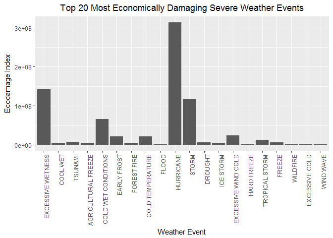

```r
perm <- order(EI$ECODMG_INDEX, decreasing = TRUE)
EI <- EI[perm,]
EI$EVTYPE <- factor(EI$EVTYPE, levels = EI$EVTYPE[perm])

library('ggplot2')

ggplot(EI[1:20,], aes(x = EVTYPE[1:20], y = ECODMG_INDEX[1:20])) +
    geom_bar(stat = 'identity') +
    xlab('Weather Event') +
    ylab('Ecodamage Index') +
    ggtitle('Top 20 Most Economically Damaging Severe Weather Events') +
    theme(axis.text.x = element_text(angle = 90, hjust = 1),
          plot.title = element_text(hjust = 0.5))
```

From the plot it seems **HURRICANE** is by far the most economically damaging severe weather event in the U.S..

## Discussion & Future Work

- Event type clean-up is not perfect. Only barely tolerable.
- While the rampant typos and lack of standard representations in the EVTYPE variable from the original data necessitates the extensive modifications to the event type descriptors, the changes made can be thought of as arbitrary and lacking systematic underlying guidelines. Since subsequent analysis uses grouping by event types it is crucial to have a logical and standard way of approaching EVTYPE corrections. However it may be impossible without further consultations with NOAA.
- Although this author believes the choice of weighting (or lack thereof) when it comes to the computations of the casualty index and ecodamage index is *reasonable*, it is based on simple gut feelings with no scientific research to justify such choices. There may very well be better algorithms already developed to represent overrall harmfulness or economic damage based on the data provided.